# Machine Learning Project

ARVIND SRIVASTAVA

21/05/2020

## R Markdown

Executive Summary: This is a report on HAR (Human Activity Recognition), which is a key research area relating to personal activity through devices such as Fitbit, Apple watches etc.In this project, we use data from accelerometers on the bodies of 6 participants. We are required to create a machine learning algorithm to predict how they will do the exercises. We will also use our ML model to predict 20 test cases.

```r
library(knitr)
library(dplyr)
library(caret)
```

```r
library(rpart)
library(rpart.plot)
library(Rcpp)
library(RColorBrewer)
library(rattle)
library(randomForest)
set.seed(12345)
```

Read the files:

[output not shown]

```
## [1] 19622   160
```

```r
ValidData <- read.csv(url("https://d396qusza40orc.cloudfront.net/predmachlearn/pml-testing.csv"),header=TRUE)


dim(ValidData)
```

```
## [1]  20 160
```

```r
str(TrainData)
```

```
## 'data.frame':    19622 obs. of  160 variables:
##  $ X                       : int  1 2 3 4 5 6 7 8 9 10 ...
##  $ user_name               : chr  "carlitos" "carlitos" "carlitos" "carlitos" ...
##  $ raw_timestamp_part_1    : int  1323084231 1323084231 1323084231 1323084232 1323084232 1323084232 1323084232 1323084232 1323084232 1323084232 ...
##  $ raw_timestamp_part_2    : int  788290 808298 820366 120339 196328 304277 368296 440390 484323 484434 ...
##  $ cvtd_timestamp          : chr  "05/12/2011 11:23" "05/12/2011 11:23" "05/12/2011 11:23" "05/12/2011 11:23" ...
##  $ new_window              : chr  "no" "no" "no" "no" ...
##  $ num_window              : int  11 11 11 12 12 12 12 12 12 12 ...
##  $ roll_belt               : num  1.41 1.41 1.42 1.48 1.48 1.45 1.42 1.42 1.43 1.45 ...
##  $ pitch_belt              : num  8.07 8.07 8.07 8.05 8.07 8.06 8.09 8.13 8.16 8.17 ...
##  $ yaw_belt                : num  -94.4 -94.4 -94.4 -94.4 -94.4 -94.4 -94.4 -94.4 -94.4 -94.4 ...
##  $ total_accel_belt        : int  3 3 3 3 3 3 3 3 3 3 ...
##  $ kurtosis_roll_belt      : chr  "" "" "" "" ...
##  $ kurtosis_picth_belt     : chr  "" "" "" "" ...
##  $ kurtosis_yaw_belt       : chr  "" "" "" "" ...
```

[output cut: 86 more lines]

Data Pre-processing-Cleaning data: Eliminate the NA and empty entries and remove the unwanted columns(whereever they exceed 90% of the total column):

```r
EmptyCols <- which(colSums(is.na(TrainData) | TrainData == "")>0.9*dim(TrainData)[1])
TrainDataClean <- TrainData[, -EmptyCols]
TrainDataClean <- TrainDataClean[, -c(1:7)] # Remove  cols 1-7
dim(TrainDataClean)
```

```
## [1] 19622    53
```

```r
EmptyCols <- which(colSums(is.na(ValidData) |ValidData=="")>0.9*dim(ValidData)[1])
ValidDataClean <- ValidData[,-EmptyCols]
ValidDataClean <- ValidDataClean[,-1]
dim(ValidDataClean)
```

```
## [1] 20 59
```

These are the 20 cases on which we have to perform validation. Now we prepare the data for prediction by splitting the training data into 60% as train data and 40% as test data. This splitting will serve to test the model accuracy.

```r
set.seed(12345)
inTrain <- createDataPartition(TrainDataClean$classe, p=0.6, list=FALSE)
TrainData <- TrainDataClean[inTrain,]
TestData <- TrainDataClean[-inTrain,]
dim(TrainData)
```

```
## [1] 11776    53
```

In order to limit the effects of overfitting, and improve the efficicency of the models, we will use the cross-validation technique. Cross-validation is done for each model with K = 3. This is done below:

```r
fitControl <- trainControl(method='cv', number = 3)
```

To ensure proper functioning of Decision trees and Random Forest Algorithm with Test data set, we need to coerce the data into same type data. First we will use Decision Tree Algorithm:

Formulating and running ML algorithm:

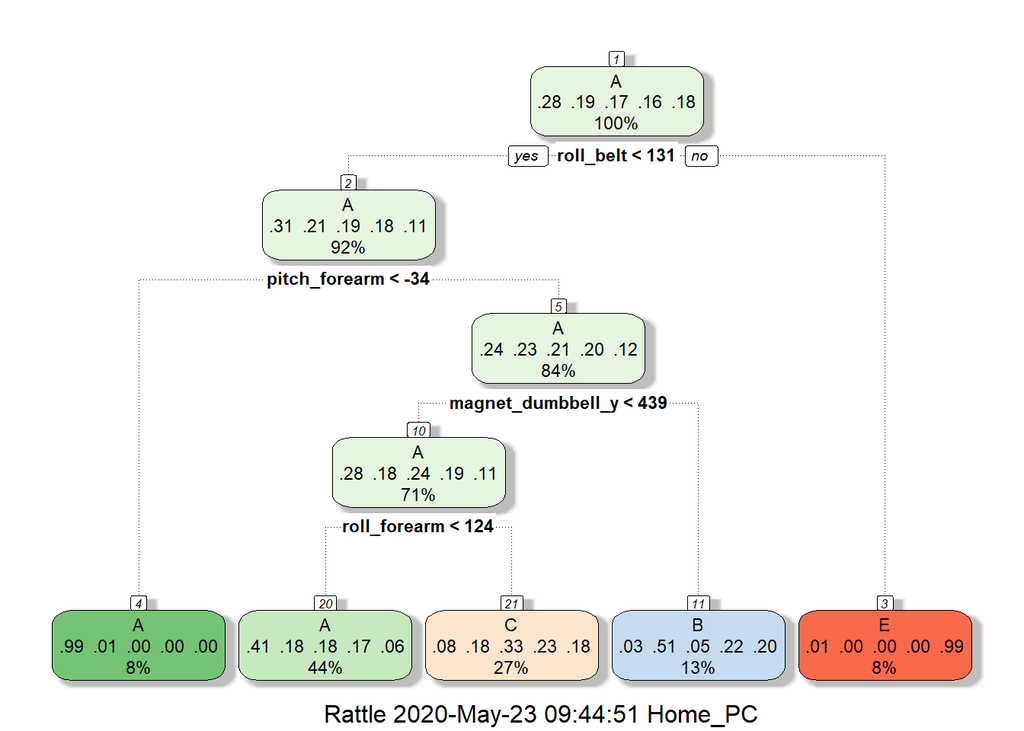

```r
DT_Model <- train(classe ~ ., data=TrainData, method = "rpart", trControl = fitControl)
fancyRpartPlot(DT_Model$finalModel) # plot the above
```

Now we validate decision tree model on test data. Predicting:

```r
DT_Predict <- predict(DT_Model, newdata = TestData)
DT_cm <- confusionMatrix(factor(TestData$classe), DT_Predict)
DT_cm
```

```
## Confusion Matrix and Statistics
##
##           Reference
## Prediction    A    B    C    D    E
##          A 2032   41  154    0    5
##          B  624  525  369    0    0
##          C  646   33  689    0    0
##          D  577  244  465    0    0
##          E  211  191  383    0  657
##
## Overall Statistics
##
##                Accuracy : 0.4975
##                  95% CI : (0.4863, 0.5086)
##     No Information Rate : 0.5213
##     P-Value [Acc > NIR] : 1
##
##                   Kappa : 0.343
##
##  Mcnemar's Test P-Value : NA
##
## Statistics by Class:
##
##                      Class: A Class: B Class: C Class: D Class: E
## Sensitivity            0.4968  0.50774  0.33447       NA  0.99245
## Specificity            0.9468  0.85423  0.88265   0.8361  0.89073
## Pos Pred Value         0.9104  0.34585  0.50365       NA  0.45562
## Neg Pred Value         0.6334  0.91956  0.78836       NA  0.99922
## Prevalence             0.5213  0.13179  0.26255   0.0000  0.08437
## Detection Rate         0.2590  0.06691  0.08782   0.0000  0.08374
## Detection Prevalence   0.2845  0.19347  0.17436   0.1639  0.18379
## Balanced Accuracy      0.7218  0.68098  0.60856       NA  0.94159
```

[output not shown]

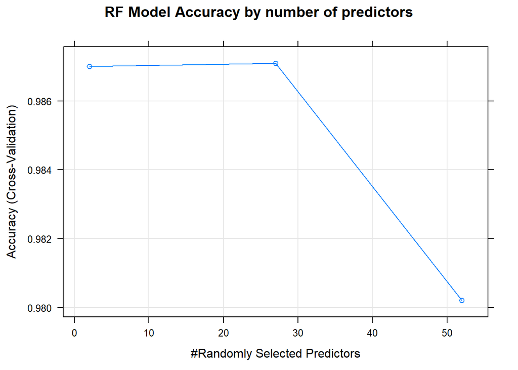

Prediction Model and Confusion Matrix

```r
RF_Predict <- predict(RF_Model, newdata=TestData)
RF_cm <- confusionMatrix(factor(TestData$classe), RF_Predict)
RF_cm
```

```
## Confusion Matrix and Statistics
##
##           Reference
## Prediction    A    B    C    D    E
##          A 2228    3    1    0    0
##          B   13 1502    3    0    0
##          C    0    4 1358    6    0
##          D    0    0    8 1278    0
##          E    0    0    3    6 1433
##
## Overall Statistics
##
##                Accuracy : 0.994
##                  95% CI : (0.992, 0.9956)
##     No Information Rate : 0.2856
##     P-Value [Acc > NIR] : < 2.2e-16
##
##                   Kappa : 0.9924
##
##  Mcnemar's Test P-Value : NA
##
## Statistics by Class:
##
##                      Class: A Class: B Class: C Class: D Class: E
## Sensitivity            0.9942   0.9954   0.9891   0.9907   1.0000
## Specificity            0.9993   0.9975   0.9985   0.9988   0.9986
## Pos Pred Value         0.9982   0.9895   0.9927   0.9938   0.9938
## Neg Pred Value         0.9977   0.9989   0.9977   0.9982   1.0000
## Prevalence             0.2856   0.1923   0.1750   0.1644   0.1826
## Detection Rate         0.2840   0.1914   0.1731   0.1629   0.1826
## Detection Prevalence   0.2845   0.1935   0.1744   0.1639   0.1838
## Balanced Accuracy      0.9967   0.9964   0.9938   0.9947   0.9993
```

By comparing the accuracy rate values of the two models, it is clear that the ‘Random Forest’ model is the better one in terms of accuracy(0.99 vs 0.49 for Decision Trees) So we will use it to predict the values of ‘classe’ for the validation data.

In fact, the very high overall accuracy of 99.40% makes it futile to go in for the General Booster Model (gbm). So, we give below our predictions on the 20 test cases pertaining to the activities of lifting barbel weights in 5 different ways: A, B, C, D and E.

```r
Prediction_Test <- predict(RF_Model,newdata=ValidDataClean)
Prediction_Test
```

```
##  [1] B A B A A E D B A A B C B A E E A B B B
## Levels: A B C D E
```

Courtesy- Groupware@LES